# DS202_lab3_Abagail_Ohmer

```r
dat <- readxl::read_xls('GSS.xls')
str(dat)
```

```
## tibble [64,814 x 9] (S3: tbl_df/tbl/data.frame)
##  $ Gss year for this respondent    : num [1:64814] 1972 1972 1972 1972 1972 ...
##  $ Respondent id number            : num [1:64814] 1 2 3 4 5 6 7 8 9 10 ...
##  $ Marital status                  : chr [1:64814] "Never married" "Married" "Married" "Married" ...
##  $ Age of respondent               : chr [1:64814] "23" "70" "48" "27" ...
##  $ Highest year of school completed: chr [1:64814] "16" "10" "12" "17" ...
##  $ Respondents sex                 : chr [1:64814] "Female" "Male" "Female" "Female" ...
##  $ Political party affiliation     : chr [1:64814] "Ind,near dem" "Not str democrat" "Independent" "Not str democrat" ...
##  $ General happiness               : chr [1:64814] "Not too happy" "Not too happy" "Pretty happy" "Not too happy" ...
##  $ Ballot used for interview       : chr [1:64814] "Not applicable" "Not applicable" "Not applicable" "Not applicable" ...
```

```r
library(ggplot2)
library(dplyr)
library(tidyverse)
dat <- dat %>% rename("Ageofrespondent" = "Age of respondent")
dat <- dat %>% mutate(Ageofrespondent = as.numeric(Ageofrespondent))
dat <- dat %>% rename("HigestSchoolComplete" = "Highest year of school completed")
dat <- dat %>% mutate(HigestSchoolComplete = as.numeric(HigestSchoolComplete))
dat <- dat %>% rename("Maritalstatus" = "Marital status")
dat <- dat %>% rename("Generalhappy" = "General happiness")
dat <- dat %>% rename("Politicalparty" = "Political party affiliation")
dat <- dat %>% rename("Sex" = "Respondents sex")
dat <- dat %>% rename("Age" = "Ageofrespondent")
```

```r
#1 Find the average years of education for the respondents with each marital status. Arrange your output in a meaningful order and print. Describe any patterns you find.

dat1 <- dat %>% select( Maritalstatus, HigestSchoolComplete)
dat1 <- dat1 %>% filter(!Maritalstatus %in% c('No answer'))
var <- dat1 %>% group_by(Maritalstatus) %>% summarize(school = mean(HigestSchoolComplete, na.rm=TRUE)) %>% arrange(school)
var
```

```
## # A tibble: 5 x 2
##   Maritalstatus school
##   <chr>          <dbl>
## 1 Widowed         11.2
## 2 Separated       11.9
## 3 Married         13.0
## 4 Divorced        13.1
## 5 Never married   13.4
```

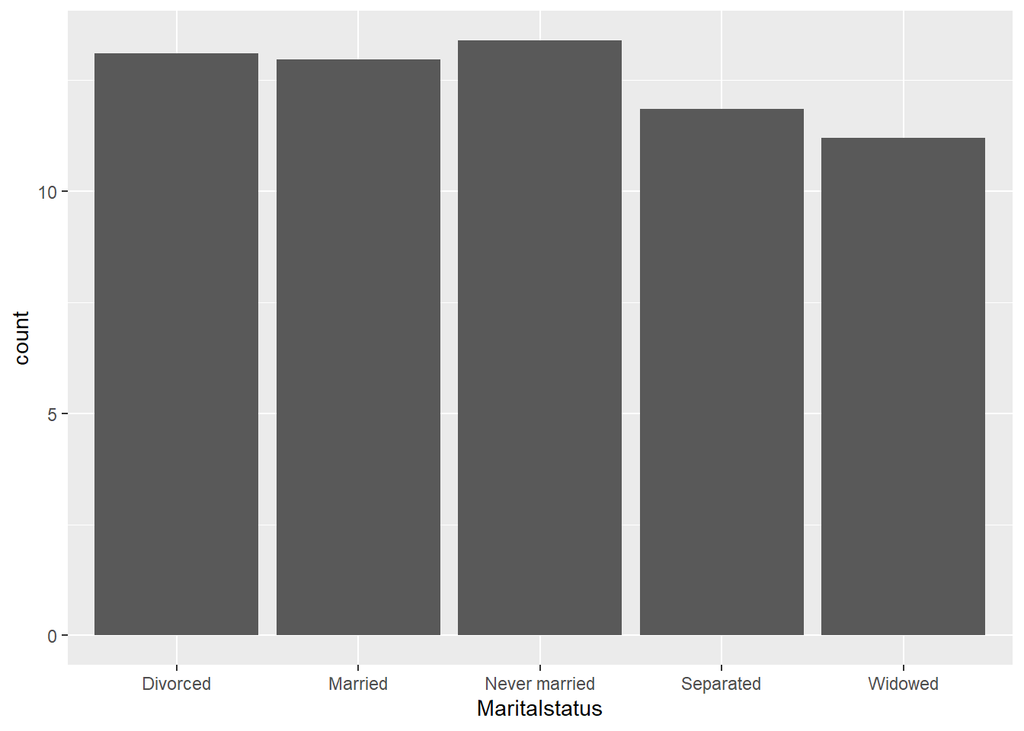

```r
ggplot(var, aes(x = Maritalstatus, weight = school)) + geom_bar()
```

The widowed have the least years of highest school completion, while the never married have the most completed years of school.

```r
#2 Create a single data frame containing records for the better educated respondents with each marital status. A “better educated” respondent is someone who has strictly more years of education than the average among those with the same marital status. Print the structure of the data frame.

dat2 <- dat %>% select( Maritalstatus, HigestSchoolComplete)
dat2 <- dat2 %>% group_by(Maritalstatus) %>% filter(HigestSchoolComplete > mean(HigestSchoolComplete, na.rm = TRUE))
str(dat2)
```

```
## grouped_df [30,714 x 2] (S3: grouped_df/tbl_df/tbl/data.frame)
##  $ Maritalstatus       : chr [1:30714] "Never married" "Married" "Never married" "Never married" ...
##  $ HigestSchoolComplete: num [1:30714] 16 17 14 16 13 14 14 17 14 13 ...
##  - attr(*, "groups")= tibble [6 x 2] (S3: tbl_df/tbl/data.frame)
##   ..$ Maritalstatus: chr [1:6] "Divorced" "Married" "Never married" "No answer" ...
##   ..$ .rows        : list<int> [1:6]
##   .. ..$ : int [1:3414] 23 41 56 77 166 208 250 304 334 378 ...
##   .. ..$ : int [1:16040] 2 5 6 7 8 10 11 12 14 15 ...
##   .. ..$ : int [1:6250] 1 3 4 9 13 17 21 22 25 28 ...
##   .. ..$ : int [1:14] 9288 10465 11676 13143 22339 22935 22950 22986 23943 26304 ...
##   .. ..$ : int [1:1458] 43 44 51 89 107 108 128 141 156 221 ...
##   .. ..$ : int [1:3538] 47 76 81 87 99 103 113 115 122 125 ...
##   .. ..@ ptype: int(0)
##   ..- attr(*, ".drop")= logi TRUE
```

```r
#3 How is the happiness of a respondent related to his/her marriage status? Define that a person is happy if the response to question is “Very happy” or “Pretty happy”.

dat3 <- dat %>% select( Maritalstatus, Generalhappy)
var3 <- dat3 %>% filter(!Generalhappy %in% c('Very happy', 'Pretty happy'))
dat3 <- dat3 %>% filter(Generalhappy %in% c('Very happy', 'Pretty happy'))
table(dat3$Generalhappy, dat3$Maritalstatus)
```

```
##
##                Divorced Married Never married No answer Separated Widowed
##   Pretty happy     4683   16493          7954        10      1148    3275
##   Very happy       1497   12849          2732         6       339    1400
```

```r
table(var3$Generalhappy, var3$Maritalstatus)
```

```
##
##                  Divorced Married Never married No answer Separated Widowed
##   Don't know            3      12            10         1         7       6
##   No answer            58     123            94         1        14      48
##   Not applicable      688    2221           992         5       146     331
##   Not too happy      1450    2431          2055         4       588    1140
```

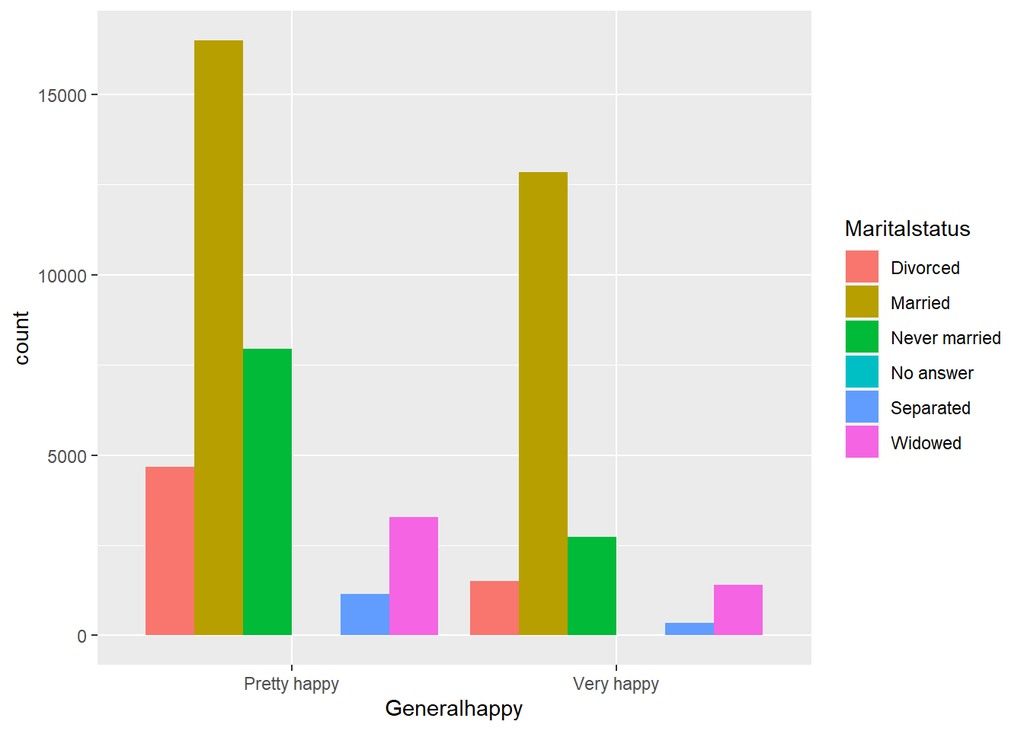

```r
ggplot(dat3, aes(x = Generalhappy, fill = Maritalstatus)) + geom_bar(position = 'dodge')
```

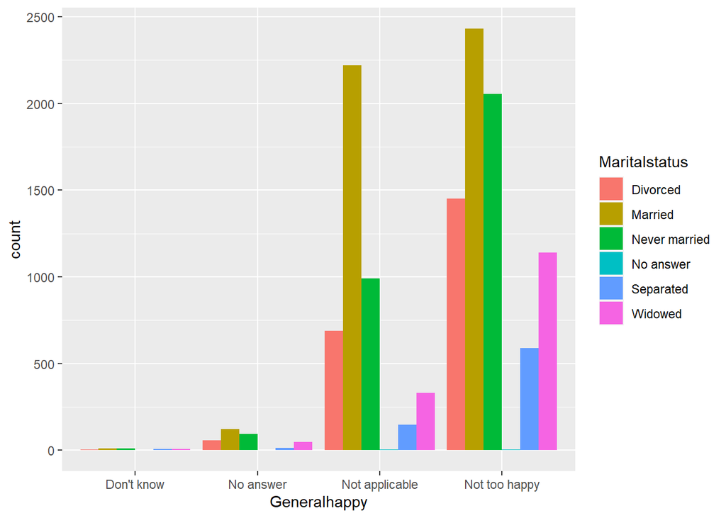

```r
ggplot(var3, aes(x = Generalhappy, fill = Maritalstatus)) + geom_bar(position = 'dodge')
```

From the two graphs we can see that in each martial status, more people are happy, than unhappy. The majority of peope who are happy are married.

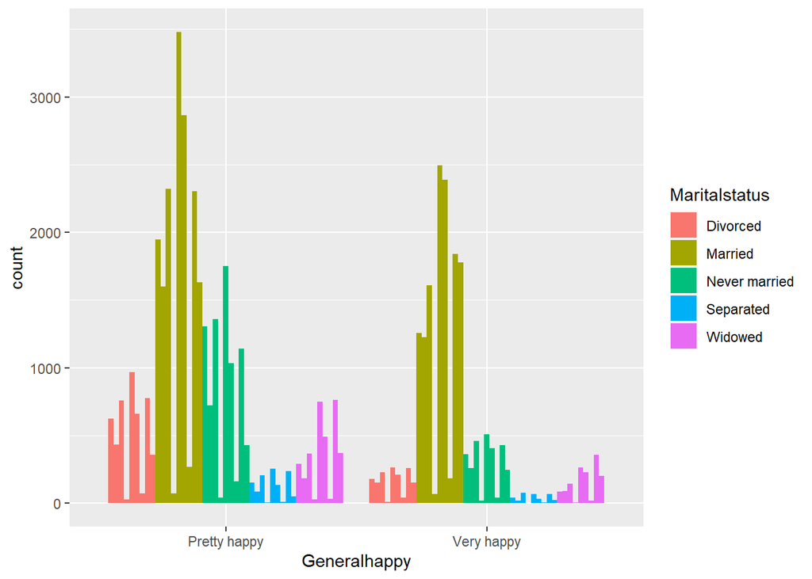

```r
#4 Does party affiliation affect the relationship you found in the last question? Explore an interesting question (not covered by the previous questions), and answer the question using the GSS data.

dat4 <- dat %>% select(Maritalstatus, Generalhappy, Politicalparty)
dat4 <- dat4 %>% filter (! (Maritalstatus == 'No answer' | Politicalparty == "Don't know"))
var4 <- dat4 %>% filter(!(Generalhappy == 'Very happy' |  Generalhappy == 'Pretty happy'))
dat4 <- dat4 %>% filter((Generalhappy == 'Very happy' | Generalhappy == 'Pretty happy'))
ggplot(dat4, aes(x = Generalhappy, fill = Maritalstatus, width = Politicalparty)) + geom_bar(position = 'dodge')
```

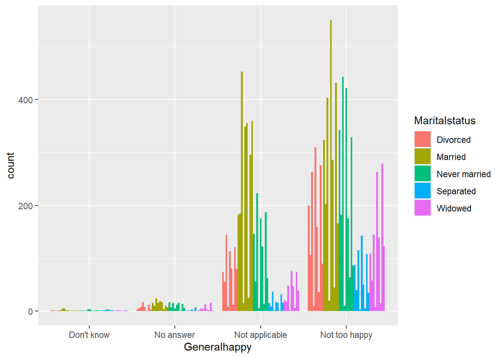

```r
ggplot(var4, aes(x = Generalhappy, fill = Maritalstatus, width = Politicalparty)) + geom_bar(position = 'dodge')
```

```r
table(var4)
```

```
## , , Politicalparty = Ind,near dem
##
##                Generalhappy
## Maritalstatus   Don't know No answer Not applicable Not too happy
##   Divorced               0         3             74           200
##   Married                0        16            182           324
##   Never married          1        17            146           342
##   Separated              2         1             15            88
##   Widowed                1         1             21           109
##
## , , Politicalparty = Ind,near rep
##
##                Generalhappy
## Maritalstatus   Don't know No answer Not applicable Not too happy
##   Divorced               0         6             55           106
##   Married                2        10            185           203
##   Never married          1         7             56           182
##   Separated              0         0              9            40
##   Widowed                0         2             18            58
##
## , , Politicalparty = Independent
##
##                Generalhappy
## Maritalstatus   Don't know No answer Not applicable Not too happy
##   Divorced               2         8            144           263
##   Married                5        24            453           404
##   Never married          4        16            223           443
##   Separated              3         1             37           115
##   Widowed                2         5             48           145
##
## , , Politicalparty = No answer
##
##                Generalhappy
## Maritalstatus   Don't know No answer Not applicable Not too happy
##   Divorced               0         0              8            10
##   Married                0        16             15            20
##   Never married          1         5              6            10
##   Separated              0         1              2             3
##   Widowed                0         4              2             8
##
```

[output cut: 34 more lines]

```
##   Divorced               0        12            121           276
##   Married                1        10            296           432
##   Never married          1        14            187           329
##   Separated              2         7             32           108
##   Widowed                1        16             74           279
##
## , , Politicalparty = Strong republican
##
##                Generalhappy
## Maritalstatus   Don't know No answer Not applicable Not too happy
##   Divorced               1         3             80            90
##   Married                1         7            360           166
##   Never married          0         6             62            86
##   Separated              0         0             16            35
##   Widowed                2         2             39           123
```

```r
table(dat4)
```

```
## , , Politicalparty = Ind,near dem
##
##                Generalhappy
## Maritalstatus   Pretty happy Very happy
##   Divorced               625        178
##   Married               1947       1256
##   Never married         1307        363
##   Separated              153         40
##   Widowed                291         87
##
## , , Politicalparty = Ind,near rep
##
##                Generalhappy
## Maritalstatus   Pretty happy Very happy
##   Divorced               435        154
##   Married               1601       1225
##   Never married          724        259
##   Separated               88         18
##   Widowed                185         91
##
## , , Politicalparty = Independent
##
##                Generalhappy
## Maritalstatus   Pretty happy Very happy
##   Divorced               757        228
##   Married               2323       1610
##   Never married         1360        462
##   Separated              207         76
##   Widowed                368        146
##
## , , Politicalparty = No answer
##
##                Generalhappy
## Maritalstatus   Pretty happy Very happy
##   Divorced                29         12
##   Married                 75         68
##   Never married           43         18
##   Separated                7          3
##   Widowed                 27          8
##
```

[output cut: 34 more lines]

```
##   Divorced               777        258
##   Married               2305       1841
##   Never married         1140        427
##   Separated              239         69
##   Widowed                763        359
##
## , , Politicalparty = Strong republican
##
##                Generalhappy
## Maritalstatus   Pretty happy Very happy
##   Divorced               360        152
##   Married               1629       1778
##   Never married          428        245
##   Separated               51         25
##   Widowed                369        200
```

Political party affiliation doesn’t affect that more people in general are happier than sad, regardless of marital status. And the majority of people who are happy are married in each political party affiliation.

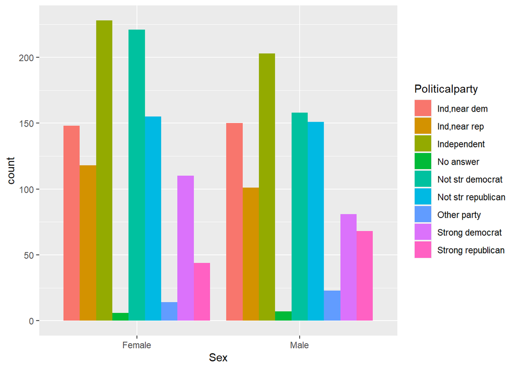

```r
#5 Explore an interesting question (not covered by the previous questions), and answer the question using the GSS data.

dat5 <- dat %>% select(Age, Sex, Politicalparty)
dat5 <- dat5 %>% filter ((!Politicalparty == "Don't know") & Age >= 18 & Age <= 20)
dat5 <- dat5 %>% group_by(Age)
ggplot(dat5, aes(x = Sex, fill = Politicalparty)) + geom_bar(position = 'dodge')
```

```r
table(dat5)
```

```
## , , Politicalparty = Ind,near dem
##
##     Sex
## Age  Female Male
##   18     21   16
##   19     61   69
##   20     66   65
##
## , , Politicalparty = Ind,near rep
##
##     Sex
## Age  Female Male
##   18     10   15
##   19     48   45
##   20     60   41
##
## , , Politicalparty = Independent
##
##     Sex
## Age  Female Male
##   18     26   28
##   19     93   88
##   20    109   87
##
## , , Politicalparty = No answer
##
##     Sex
## Age  Female Male
##   18      1    0
##   19      4    3
##   20      1    4
##
## , , Politicalparty = Not str democrat
##
##     Sex
## Age  Female Male
##   18     32   20
##   19     86   69
##   20    103   69
##
```

[output cut: 16 more lines]

```
## , , Politicalparty = Strong democrat
##
##     Sex
## Age  Female Male
##   18     15    9
##   19     46   35
##   20     49   37
##
## , , Politicalparty = Strong republican
##
##     Sex
## Age  Female Male
##   18      1   11
##   19     21   31
##   20     22   26
```

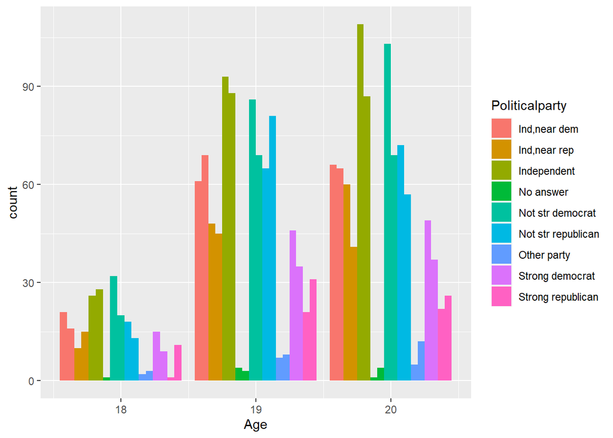

```r
ggplot(dat5, aes(x = Age, fill = Politicalparty, width = Sex)) + geom_bar(position = 'dodge')
```

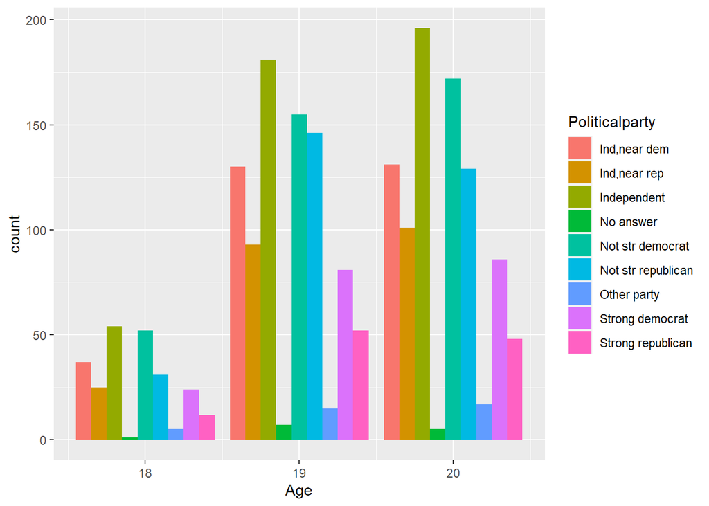

```r
ggplot(dat5, aes(x = Age, fill = Politicalparty)) + geom_bar(position = 'dodge')
```

In the second graph, We can see the comparison of political party affiliation, age between 18 and 20, and sex (females in the first column, then males). The graphs for each age group, keep the proportions for each political party affiliation the same, but the number of people asked for each age group increases. We can also see that almost every party affiliation grows as the age increases, but between the ages of 19 and 20, no answer decreases for females and increases for males.

The last graph looks at the relationship between ages 18 - 20 and political party affiliation, regardless of sex. We can see that more people were asked as age increases, and that almost every party affiliation increases as age increases.